# Effects of different features on the bank loans system

What factors affect a loan’s outcome status?

What affects the borrower’s APR or interest rate?

Are there differences between loans depending on how large the original loan amount was?

## Investigation Overview

In this investigation, I wanted to look at the different features that could be used to predict their acceptance and rejection of new loans. The main focus was on the loan assesment, interest rates, and Loan amounts.

## Dataset Overview

The data consisted of outcomes and attributes of approximately 113,937 different loans.

## Distribution of amount of loans

Amount of loans are right skewed with some peaks in the 5k multipactives like (5k, 10k, 15k, 20k, 25k)

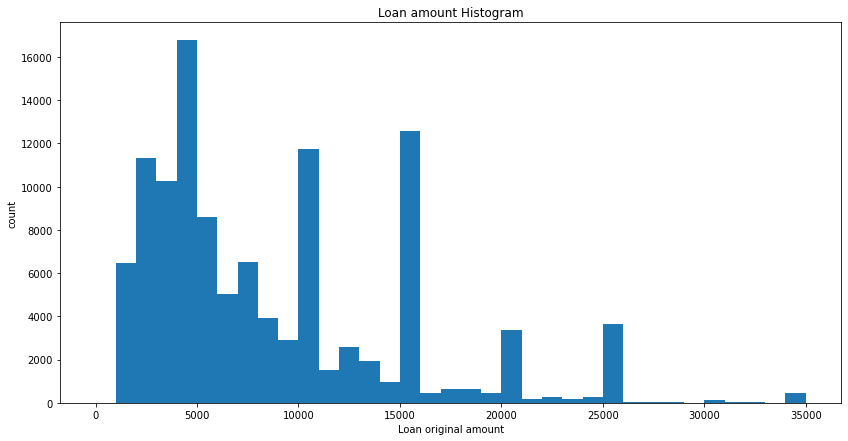

## Distribution of status of loans

Loans are classified into many classifications, we made a distribution to show how is it classified according to the counts of classifications.

Then we made the classification simpler to be visually more appealing to comperhend.

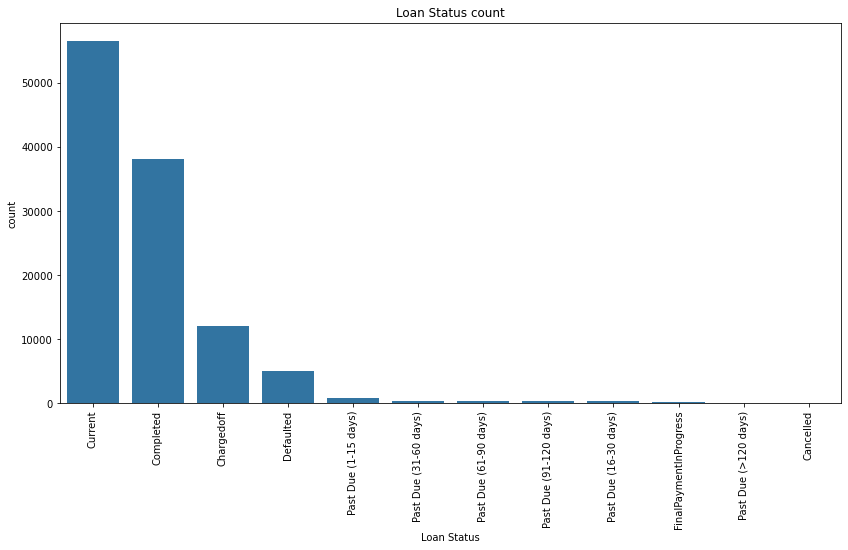

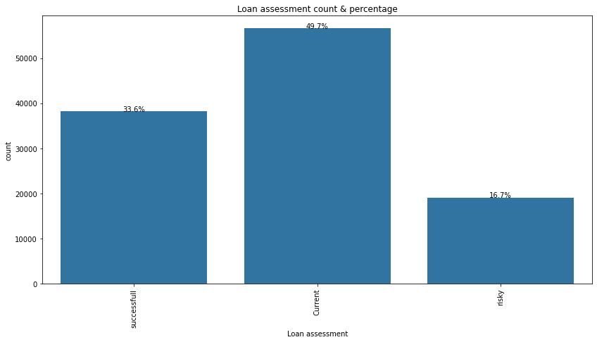

## Employment Status & Time vs. Loan assesment

Investigation if Employment status is having a strong relationship with the probability of success of a loan for the bank, what was noted here is that part timers having a higher success rate than full timers.

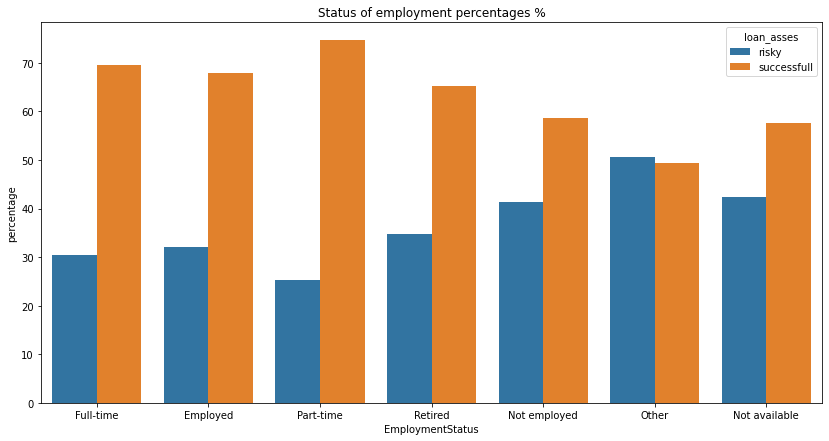

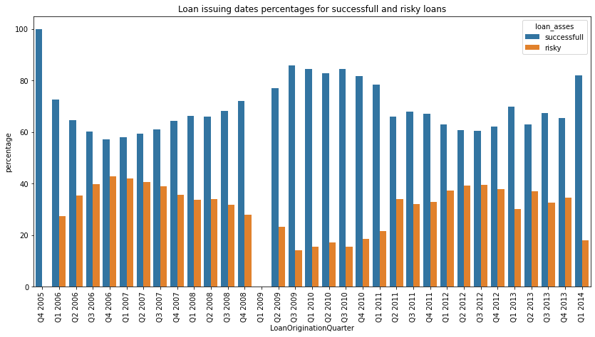

## Question number 1 : What factors affect a loan’s outcome status?

## Loan outcome vs predicting factors

#### **Main factors affecting loan outcomes here are :**

```
Index(['loan_asses', 'LoanMonthsSinceOrigination',
       'LP_CustomerPrincipalPayments', 'LoanOriginalAmount', 'Term',
       'EstimatedReturn', 'Investors', 'ProsperPrincipalOutstanding'],
      dtype='object')
```

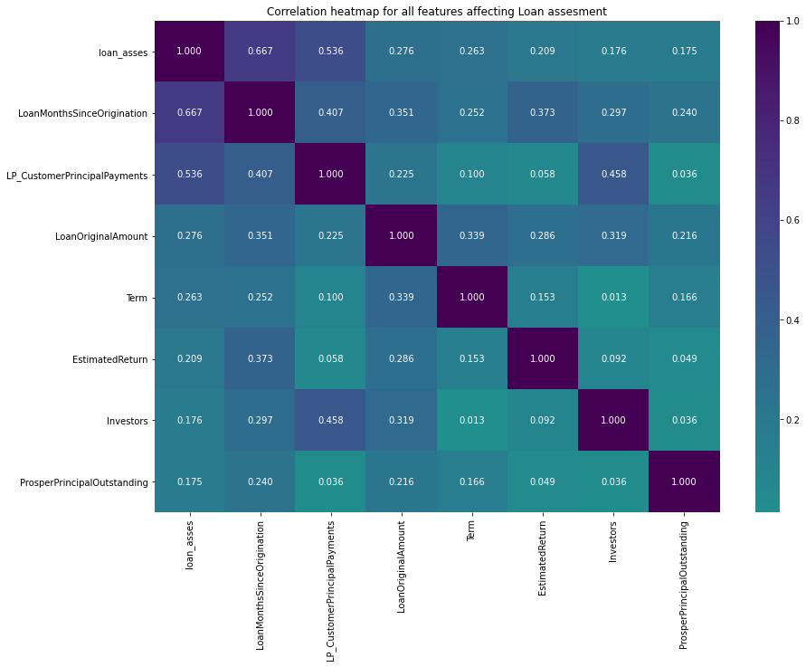

### Question number 2 : What affects the borrower’s APR or interest rate?

#### **Main factors affecting interest rate here are :**

- **ProsperScore** : The more score can decrease the interest rate on the loan, as it is an indication of a low risk client.
- **credit score range** : The more score can decrease the interest rate on the loan, as it is an indication of a low risk client.
- **Available Bank card credit** : The total available credit via bank card can have an effect on the interest rate given by bank.

```
Index(['BorrowerAPR', 'EstimatedReturn', 'InquiriesLast6Months',
       'BankcardUtilization', 'LoanMonthsSinceOrigination',
       'LP_InterestandFees', 'ProsperScore', 'CreditScoreRangeLower',
       'LoanOriginalAmount', 'AvailableBankcardCredit',
       'TradesNeverDelinquent (percentage)'],
      dtype='object')
```

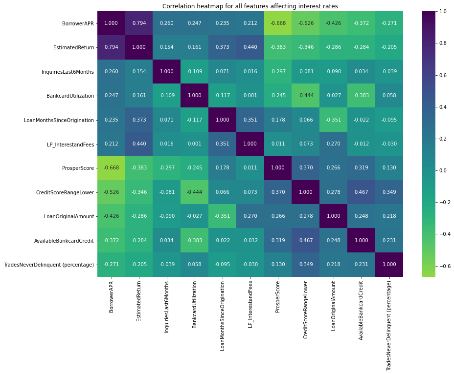

#### **Further investigation into these features :**

This plot suggests from the direct relationship between the increasing rate of interest and estimated yield.

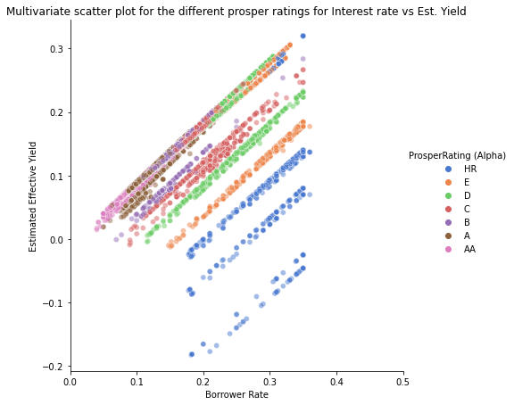

### Question number 3 : to see if there are differences between loans depending on how large the original loan amount was?

#### **Main factors affecting original loan amounts here are :**

```
Index(['LoanOriginalAmount', 'ProsperRating (numeric)',
       'ProsperPrincipalBorrowed', 'LoanNumber', 'Term', 'Investors',
       'CreditScoreRangeLower', 'LP_ServiceFees', 'EstimatedReturn',
       'loan_asses', 'ListingCategory (numeric)'],
      dtype='object')
```

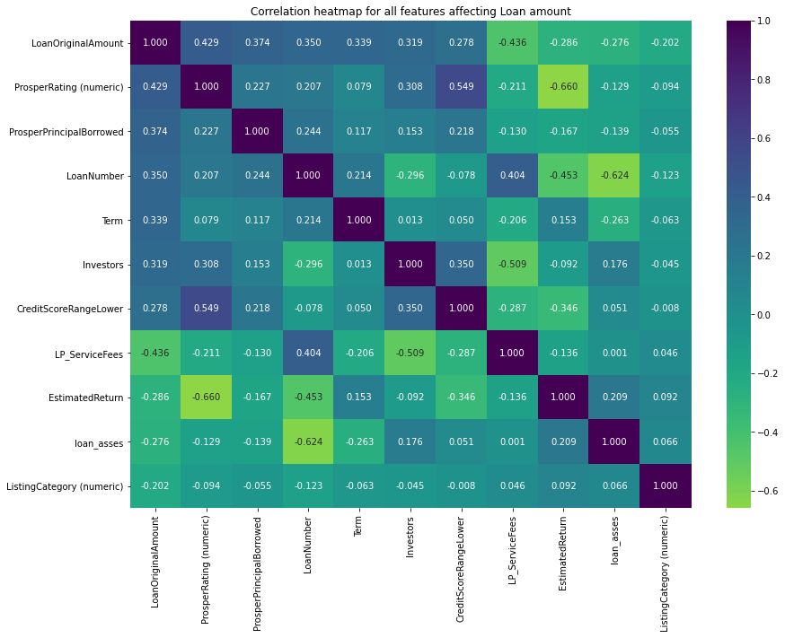

#### **Further investigation Listing category vs Loan amount :**

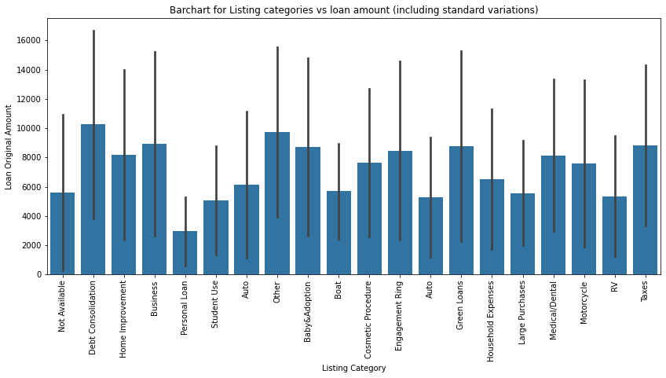

## Relationship between different features and each other

Reproducing plot matrix of numeric features against categorical features, to see the different relationships between each other.

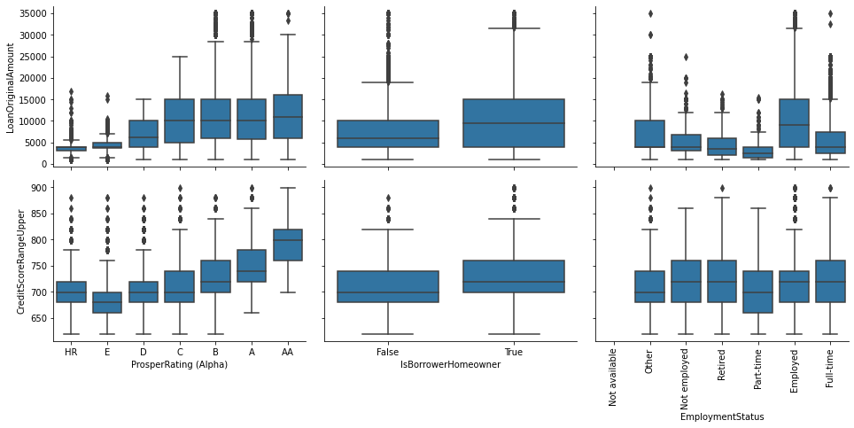